# Predictors of MPG

# Synopsis

There were two objective for this assignment:

- Assess whether an automatic or manual transmission is better for MPG
- Quantify the difference in MPG between automatic and manual transmissions

After importing and cleaning the data, I performed an initial t-test to assess if there was a difference in MPG between automatic and manual transmissions, and there was. I then created a series of models to determine if the observed differences could be (partially) explained by other variables. I concluded that, when holding other variables constant, there is not a meaningful difference in MPG between automatic and manual transmission vehicles.

The following packages are needed to replicate this analysis.

```r
library(ggplot2); library(dplyr); library(plyr); library(gridExtra)
```

# Viewing

```r
dat <- mtcars
head(dat)
```

```
##                    mpg cyl disp  hp drat    wt  qsec vs am gear carb
## Mazda RX4         21.0   6  160 110 3.90 2.620 16.46  0  1    4    4
## Mazda RX4 Wag     21.0   6  160 110 3.90 2.875 17.02  0  1    4    4
## Datsun 710        22.8   4  108  93 3.85 2.320 18.61  1  1    4    1
## Hornet 4 Drive    21.4   6  258 110 3.08 3.215 19.44  1  0    3    1
## Hornet Sportabout 18.7   8  360 175 3.15 3.440 17.02  0  0    3    2
## Valiant           18.1   6  225 105 2.76 3.460 20.22  1  0    3    1
```

```r
str(dat)
```

```
## 'data.frame':    32 obs. of  11 variables:
##  $ mpg : num  21 21 22.8 21.4 18.7 18.1 14.3 24.4 22.8 19.2 ...
##  $ cyl : num  6 6 4 6 8 6 8 4 4 6 ...
##  $ disp: num  160 160 108 258 360 ...
##  $ hp  : num  110 110 93 110 175 105 245 62 95 123 ...
##  $ drat: num  3.9 3.9 3.85 3.08 3.15 2.76 3.21 3.69 3.92 3.92 ...
##  $ wt  : num  2.62 2.88 2.32 3.21 3.44 ...
##  $ qsec: num  16.5 17 18.6 19.4 17 ...
##  $ vs  : num  0 0 1 1 0 1 0 1 1 1 ...
##  $ am  : num  1 1 1 0 0 0 0 0 0 0 ...
##  $ gear: num  4 4 4 3 3 3 3 4 4 4 ...
##  $ carb: num  4 4 1 1 2 1 4 2 2 4 ...
```

# Recoding

The `am`, `vs`, and `cyl` variables were recoded as factors.

```r
## RECODING
dat$am <- as.factor(mapvalues(dat$am, c(0,1), c("Automatic", "Manual")))
dat$vs <- as.factor(mapvalues(dat$vs, c(0,1), c("V-shaped", "Straight")))
dat$cyl <- as.factor(dat$cyl)
```

# Data Summary

```r
# DATA SUMMARY
summary(dat)
```

```
##       mpg        cyl         disp             hp             drat
##  Min.   :10.40   4:11   Min.   : 71.1   Min.   : 52.0   Min.   :2.760
##  1st Qu.:15.43   6: 7   1st Qu.:120.8   1st Qu.: 96.5   1st Qu.:3.080
##  Median :19.20   8:14   Median :196.3   Median :123.0   Median :3.695
##  Mean   :20.09          Mean   :230.7   Mean   :146.7   Mean   :3.597
##  3rd Qu.:22.80          3rd Qu.:326.0   3rd Qu.:180.0   3rd Qu.:3.920
##  Max.   :33.90          Max.   :472.0   Max.   :335.0   Max.   :4.930
##        wt             qsec              vs             am          gear
##  Min.   :1.513   Min.   :14.50   Straight:14   Automatic:19   Min.   :3.000
##  1st Qu.:2.581   1st Qu.:16.89   V-shaped:18   Manual   :13   1st Qu.:3.000
##  Median :3.325   Median :17.71                                Median :4.000
##  Mean   :3.217   Mean   :17.85                                Mean   :3.688
##  3rd Qu.:3.610   3rd Qu.:18.90                                3rd Qu.:4.000
##  Max.   :5.424   Max.   :22.90                                Max.   :5.000
##       carb
##  Min.   :1.000
##  1st Qu.:2.000
##  Median :2.000
##  Mean   :2.812
##  3rd Qu.:4.000
##  Max.   :8.000
```

# Hypothesis Test

A two sample t-test could be used to assess if there is a significant difference between MPG of manual and automatic vehicles.

```r
t.test(dat$mpg[dat$am == "Automatic"], dat$mpg[dat$am == "Manual"])
```

```
##
##  Welch Two Sample t-test
##
## data:  dat$mpg[dat$am == "Automatic"] and dat$mpg[dat$am == "Manual"]
## t = -3.7671, df = 18.332, p-value = 0.001374
## alternative hypothesis: true difference in means is not equal to 0
## 95 percent confidence interval:
##  -11.280194  -3.209684
## sample estimates:
## mean of x mean of y
##  17.14737  24.39231
```

# Model Comparison

I created 3 linear models to assess the relationship between MPG and transmission type:

1. `lm(mpg ~ am + wt, data = dat)`
2. `lm(mpg ~ am + wt + hp, data = dat)`
3. `lm(mpg ~ am + wt + hp + cyl, data = dat)`

```r
# MODELING
mod1 <- lm(mpg ~ am + wt, data = dat)
summary(mod1)
```

```
##
## Call:
## lm(formula = mpg ~ am + wt, data = dat)
##
## Residuals:
##     Min      1Q  Median      3Q     Max
## -4.5295 -2.3619 -0.1317  1.4025  6.8782
##
## Coefficients:
##             Estimate Std. Error t value Pr(>|t|)
## (Intercept) 37.32155    3.05464  12.218 5.84e-13 ***
## amManual    -0.02362    1.54565  -0.015    0.988
## wt          -5.35281    0.78824  -6.791 1.87e-07 ***
## ---
## Signif. codes:  0 '***' 0.001 '**' 0.01 '*' 0.05 '.' 0.1 ' ' 1
##
## Residual standard error: 3.098 on 29 degrees of freedom
## Multiple R-squared:  0.7528, Adjusted R-squared:  0.7358
## F-statistic: 44.17 on 2 and 29 DF,  p-value: 1.579e-09
```

```r
# MODELING
mod2 <- lm(mpg ~ am + wt + hp, data = dat)
summary(mod2)
```

```
##
## Call:
## lm(formula = mpg ~ am + wt + hp, data = dat)
##
## Residuals:
##     Min      1Q  Median      3Q     Max
## -3.4221 -1.7924 -0.3788  1.2249  5.5317
##
## Coefficients:
##              Estimate Std. Error t value Pr(>|t|)
## (Intercept) 34.002875   2.642659  12.867 2.82e-13 ***
## amManual     2.083710   1.376420   1.514 0.141268
## wt          -2.878575   0.904971  -3.181 0.003574 **
## hp          -0.037479   0.009605  -3.902 0.000546 ***
## ---
## Signif. codes:  0 '***' 0.001 '**' 0.01 '*' 0.05 '.' 0.1 ' ' 1
##
## Residual standard error: 2.538 on 28 degrees of freedom
## Multiple R-squared:  0.8399, Adjusted R-squared:  0.8227
## F-statistic: 48.96 on 3 and 28 DF,  p-value: 2.908e-11
```

```r
# MODELING
mod3 <- lm(mpg ~ am + wt + hp + cyl, data = dat)
summary(mod3)
```

```
##
## Call:
## lm(formula = mpg ~ am + wt + hp + cyl, data = dat)
##
## Residuals:
##     Min      1Q  Median      3Q     Max
## -3.9387 -1.2560 -0.4013  1.1253  5.0513
##
## Coefficients:
##             Estimate Std. Error t value Pr(>|t|)
## (Intercept) 33.70832    2.60489  12.940 7.73e-13 ***
## amManual     1.80921    1.39630   1.296  0.20646
## wt          -2.49683    0.88559  -2.819  0.00908 **
## hp          -0.03211    0.01369  -2.345  0.02693 *
## cyl6        -3.03134    1.40728  -2.154  0.04068 *
## cyl8        -2.16368    2.28425  -0.947  0.35225
## ---
## Signif. codes:  0 '***' 0.001 '**' 0.01 '*' 0.05 '.' 0.1 ' ' 1
##
## Residual standard error: 2.41 on 26 degrees of freedom
## Multiple R-squared:  0.8659, Adjusted R-squared:  0.8401
## F-statistic: 33.57 on 5 and 26 DF,  p-value: 1.506e-10
```

```r
anova(mod1, mod2, mod3)
```

```
## Analysis of Variance Table
##
## Model 1: mpg ~ am + wt
## Model 2: mpg ~ am + wt + hp
## Model 3: mpg ~ am + wt + hp + cyl
##   Res.Df    RSS Df Sum of Sq       F    Pr(>F)
## 1     29 278.32
## 2     28 180.29  1    98.029 16.8762 0.0003525 ***
## 3     26 151.03  2    29.265  2.5191 0.0999982 .
## ---
## Signif. codes:  0 '***' 0.001 '**' 0.01 '*' 0.05 '.' 0.1 ' ' 1
```

Th ANOVA printout shows that the 2nd model is significantly better than the 1st, but the 3rd model isn’t much better than the 2nd So, I’ll use the 2nd model. I also chose the 2nd model because the 3rd model splits the subgroups by cylinder size, which lead to very small sample sizes:

```r
table(dat$am, dat$cyl)
```

```
##
##              4  6  8
##   Automatic  3  4 12
##   Manual     8  3  2
```

Referring back to the 2nd model, you can see that the `amManual` is not significant; this suggests that **there is not a meaningful difference in MPG between automatic and manual transmission vehicles when holding weight and horsepower constant**.

# Diagnostics

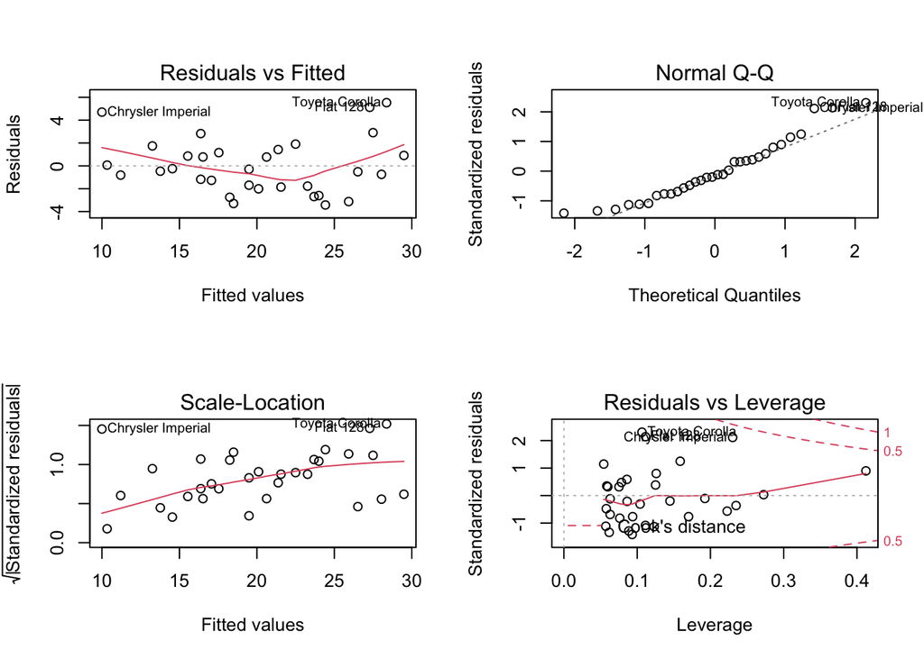

```r
par(mfrow = c(2, 2))
plot(mod2)
```

The diagnostics for this model are fairly good. The normal Q-Q plot has several points that do not align with the theoretical quantiles, but these points do not appear to have much leverage.

# Summary

# Supporting Figures

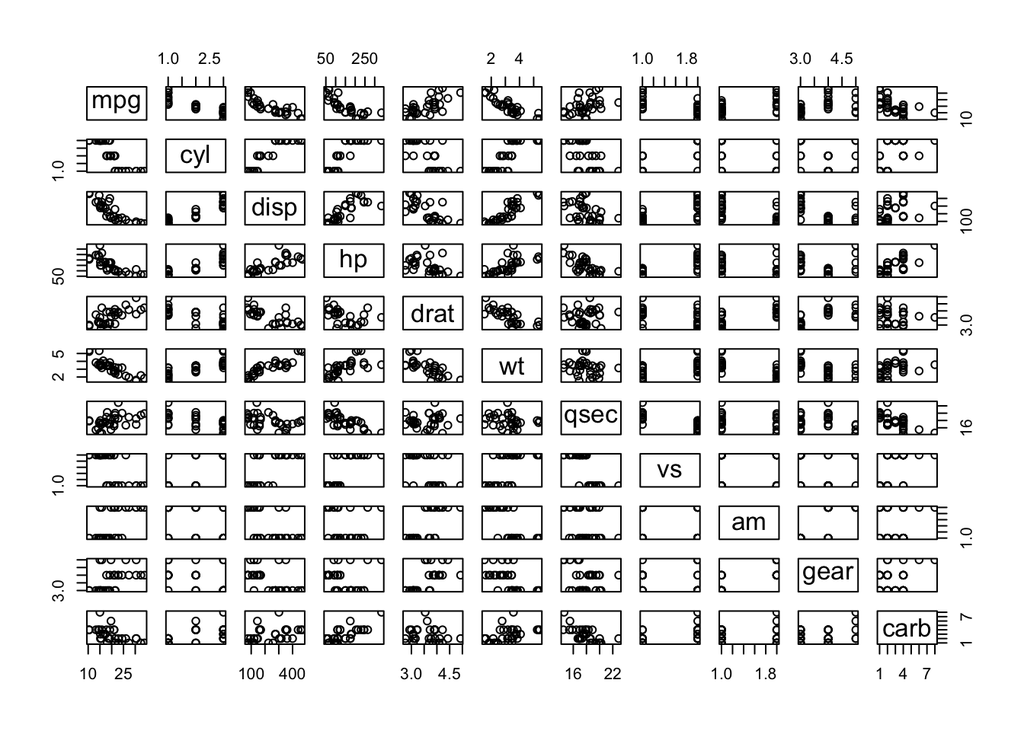

```r
plot(dat)
```

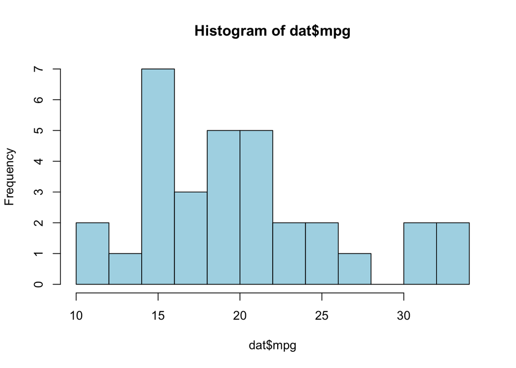

```r
hist(dat$mpg, col = "lightblue", breaks = 10)
```

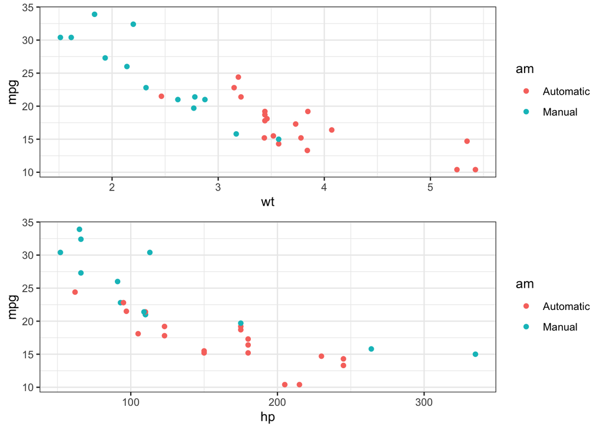

```r
p1 <-
ggplot(dat, aes(wt, mpg, col= am))+
  geom_point() +
  theme_bw()

p2 <-
ggplot(dat, aes(hp, mpg, col= am))+
  geom_point() +
  theme_bw()

gridExtra::grid.arrange(p1, p2)
```

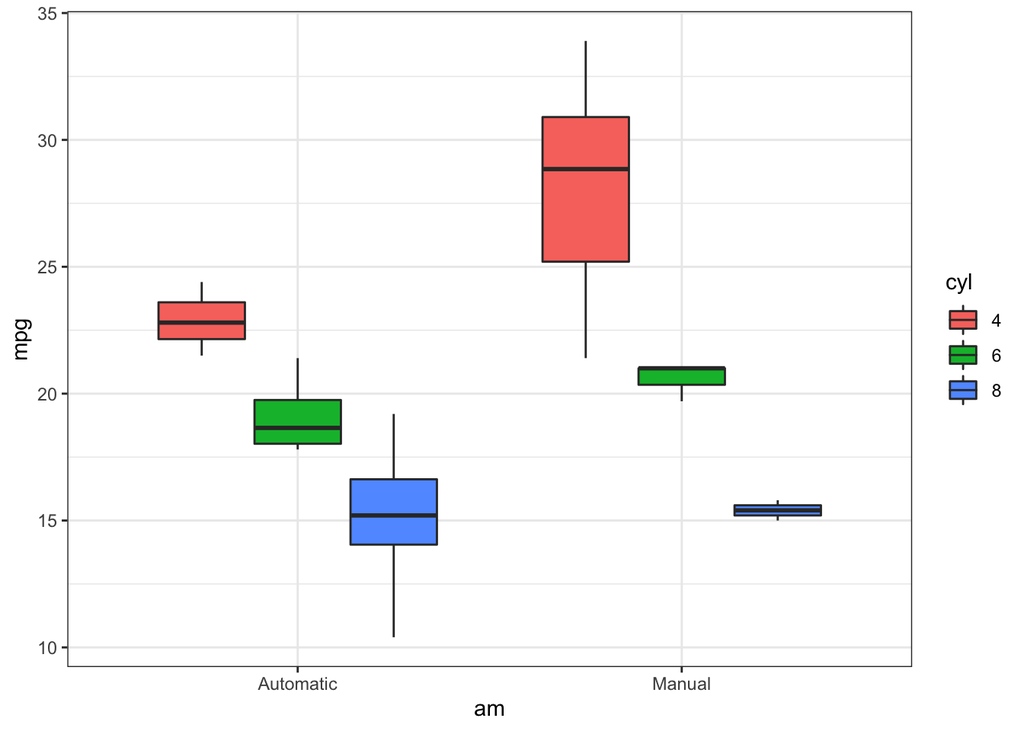

```r
ggplot(dat, aes(x = am, y = mpg, fill = cyl)) +
  geom_boxplot() +
  theme_bw()
```